# Influencia de los videojuegos en el desarrollo académico de estudiantes de universidades de Lima, Perú, en 2022

# **II. Introducción**

## Relevancia

Existe la creencia de que, en las universidades de Lima, un gran porcentaje de alumnado se considera ‘gamer’. Según la Universidad Internacional de Valencia, entendemos que un ‘gamer’ es aquella persona que juega a los videojuegos, pese a no ser necesariamente de forma profesional (VIU, 2018). Tomando esto en cuenta, decidimos armar una investigación que calcule los porcentajes de población gamer en las universidades de Lima (con una muestra de porcentaje mayor en la universidad UTEC); pero además, que determine si existe o no una relación entre la afinidad de los estudiantes por los videojuegos y su desarrollo académico en el año 2022. Para ello, decidimos evaluar la correlación entre variables como las horas o el dinero invertidos por los estudiantes en videojuegos y su promedio académico u horas invertidas en el estudio.

Los videojuegos son un medio de entretenimiento del que la mayoría de personas tienen una opinión distinta, por lo que, considerando las variables adecuadas, tendremos suficientes datos como para realizar un análisis estadístico y probabilístico sustentable y obtener conclusiones respaldadas a partir del mismo.

## Objetivos

**Objetivo Principal**

- El objetivo principal del presente informe estadístico es hallar relaciones entre las variables descritas más adelante, con el fin de analizar la influencia de los videojuegos en los desempeños académicos de los estudiantes de universidades de Lima en el año 2022.

**Objetivos Específicos**

- Identificar qué tanto influyen los videojuegos en los estudios universitarios y ver si el jugar más videojuegos afecta en algo a los promedios y horas de estudio de los estudiantes/encuestados.
- Verificar si las horas invertidas en videojuegos por los alumnos aumentó o disminuyó en la pandemia.
- Examinar si los estudiantes dedican más tiempo a jugar videojuegos que a sus estudios universitarios.

# **III. Datos**

## Proceso de recolección de datos

La recolección de datos fue realizada mediante el método de encuesta a por lo menos 200 estudiantes, a través de un Google Forms distribuido por redes sociales tales como Instagram, Whatsapp o Telegram, con el fin de llegar a conocimiento de bastantes alumnos. Debido a que el círculo más cercano de los integrantes del grupo es de la universidad UTEC, evidenciamos que la muestra tenía un porcentaje de población muy alto respecto a alumnos de esta universidad. La fecha de esta recolección se inició el día 25 de abril del 2022, y la última observación se obtuvo el 21 de junio del 2022.

## Población, muestra y muestreo

Nuestra población objetivo para el estudio son estudiantes de universidades de Lima, Perú, para saber sobre su afinidad por los videojuegos y la influencia que esta tiene en su desempeño académico en el año 2022. La muestra recolectada para la presentación de este informe hasta el día 21 de junio a las 1:20am contiene 14 variables y 206 observaciones. El tipo de muestreo probabilístico aplicado a este caso es aleatorio simple.

## Variables

### Clasificación de variables

#### Categóricas (8)

##### Nominales (6)

| Variable | Descripción | Restricción |
| --- | --- | --- |
| Sexo | Sexo | Masculino,Femenino u Otro |
| Universidad | Entidad educativa | Universidades de Lima |
| Carrera | Carrera que estudia el/la encuestada | No hay |
| Gamer | Si el encuestado se considera Gamer o no | Si o no |
| Plataforma | Plataforma más utilizada por el encuestado | Dispositivo con posibilidad de jugar videojuegos |
| Genero_favorito | Género de videojuego de preferencia del encuestado | No hay |

##### Ordinales (2)

| Variable | Descripción | Restricción |
| --- | --- | --- |
| Dinero | Cuánto dinero ha invertido en videojuegos el encuestado | Rangos: 0; 0-100; 100-1000; 1000-2000; 2000-5000; 5000-10000 y más de 10000 |
| Afecta | Si el jugar videojuegos afecto en los estudios del encuestado | Escala del 1 al 5 |

#### Numéricas (6)

##### Discretas (5)

| Variable | Descripción | Restricción |
| --- | --- | --- |
| Edad | Edad que posee el/la encuestado/a | No hay |
| Edad_videojuegos | Edad en la que el encuestado empezó a jugar videojuegos | No hay |
| Horas_pandemia | Horas semanales que dedicó el encuestado a jugar videojuegos durante el inicio de la pandemia | Entero positivo menor a 168 |
| Horas_actuales | Horas semanales que dedica el encuestado a jugar videojuegos | Entero positivo menor a 168 |
| Horas_estudio | Horas actuales que dedica el encuestado personalmente al estudio | Entero positivo menor a 168 |

##### Continuas (1)

| Variable | Descripción | Restricción |
| --- | --- | --- |
| Promedio | El promedio ponderado de la carrera universitaria del encuestado hasta la fecha | Valor entre 0 y 20 |

### Descripción de las variables

| Variable | Descripción |
| --- | --- |
| 1.Sexo | Esta variable hace referencia a las características biológicas del encuestado |
| 2.Edad | Esta variable indica la edad que tiene el encuestado |
| 3.Universidad | Esta variable precisa la casa de estudios del encuestado |
| 4.Carrera | Esta variable indica la carrera que el encuestado está estudiando actualmente |
| 5.Promedio | Esta variable mide el promedio ponderado de la carrera universitaria del encuestado |
| 6.Gamer | Variable que indica si el encuestado se considera o no gamer |
| 7.Edad_videojuegos | Esta variable indica la edad en la que el encuestado considera que empezó a jugar videojuegos |
| 8.Plataforma | Esta variable indica la plataforma en la que el encuestado pasa mas hora jugando videojuegos |
| 9.Genero_favorito | Esta variable indica el género favorito de videojuegos del encuestado |
| 10.Dinero | Esta variable nos da una idea de cuánto dinero ha invertido el encuestado en videojuegos,plataformas y/o compras dentro del mismo juego |
| 11.Horas_pandemia | Esta variable nos indica la cantidad de horas semanales que le dedicaba el encuestado a jugar videojuegos durante el inicio de la pandemia |
| 12.Horas_actuales | Esta variable nos indica la cantidad de horas semanales que le dedica el encuestado a jugar videojuegos actualmente |
| 13.Horas_estudio | Esta variable nos indica la cantidad de horas semanales de estudio que dedica el encuestado para la universidad |
| 14.Afecta | Esta variable nos da una percepción empática del mismo encuestado, referente a que si considera o no que el jugar videojuegos, afecta en su rendimiento académico |

## **Limpieza de base de datos**

### Librerías y funciones

Librerías: library(readr), library(dplyr), library(tidyr), library(ggplot2), library(stringr), library(psych)

Funciones: redondeo(x)

### Variables eliminadas

“Marca temporal”, una variable creada por google forms que especifica la hora de envío del formulario.

### Consideraciones para la limpieza

Solo permitir entradas razonables para cada variable (e.g. no más de 100 horas jugadas a la semana).

Eliminar tildes, emplear mayúsculas prudentemente, usar underscores para convertir todos los strings en palabras únicas y abreviar strings largos con acrónimos fueron consideraciones principales para formatear las observaciones uniformemente. Toda respuesta igual a “Nada” o “Ninguno” se convirtió en un NA. Se seleccionaron solo las variables más relevantes para el estudio.

# **IV. Análisis descriptivo**

## **Análisis por variable**

### Barplot de la variable Sexo:

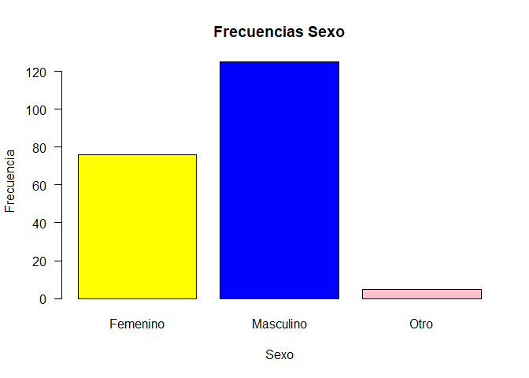

```r
barplot(table(DFN$Sexo),main="Frecuencias Sexo", xlab ="Sexo", ylab= "Frecuencia", col = c("yellow","blue", "pink"),las=1)
```

### Histograma de la variable Edad:

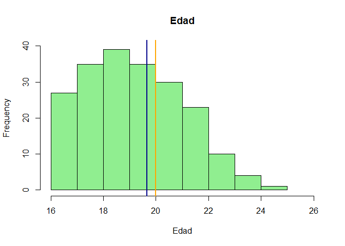

```r
hist(DFN$Edad,main="Edad", xlab="Edad", breaks=10, xlim = c(16, 26), ylim = c(0, 40), col = "Lightgreen")
abline(v=mean(DFN$Edad,na.rm=TRUE),col="darkblue",lwd=2)
abline(v=median(DFN$Edad,na.rm=TRUE),col="orange",lwd=2)
```

#### Descriptores de tendencia y variación de la variable Edad:

```r
summary(DFN$Edad)
```

```
##    Min. 1st Qu.  Median    Mean 3rd Qu.    Max.    NA's
##   16.00   18.00   20.00   19.66   21.00   25.00       2
```

Desviación Estándar:

```r
SD = sd(DFN$Edad, na.rm=TRUE)
redondeo(SD)
```

```
## [1] 1.91
```

Varianza:

```r
redondeo(var(DFN$Edad, na.rm=TRUE))
```

```
## [1] 3.65
```

Coeficiente de variación:

```r
CV = (SD / mean(DFN$Edad,na.rm=TRUE)) * 100
redondeo(CV)
```

```
## [1] 9.72
```

### Barplot de la variable Universidad:

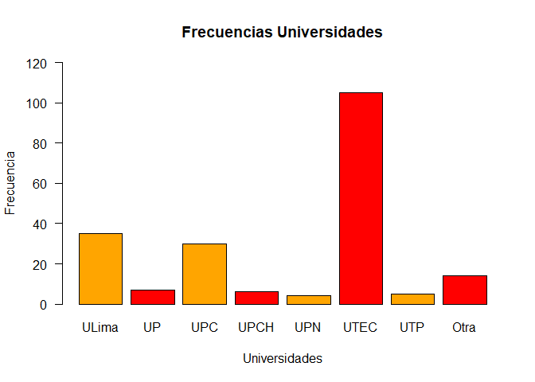

```r
barplot(table(DFN$Universidad),main="Frecuencias Universidades",ylim = c(0, 120), xlab ="Universidades", ylab= "Frecuencia", col = c("orange","red"),las=1)
```

### Barplot de la variable Carrera:

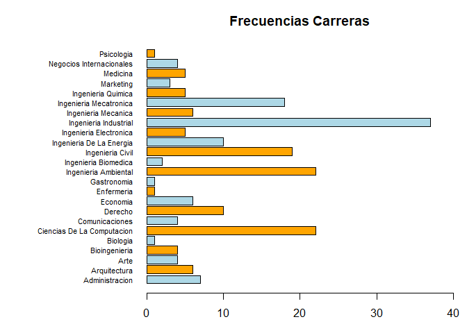

```r
par(mar=c(3,11,3,1))
barplot(table(DFN$Carrera),main="Frecuencias Carreras",las=1,horiz=TRUE, xlim=c(0,40),col=c("light blue","orange"), cex.names=0.70)
```

### Histograma de la variable Promedio_ponderado:

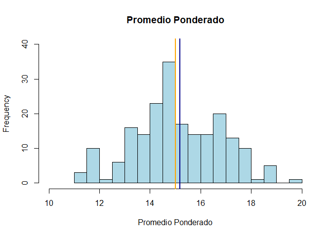

```r
hist(DFN$Promedio_ponderado,main="Promedio Ponderado", xlab="Promedio Ponderado", breaks=20, xlim = c(10, 20), ylim = c(0, 40), col = "lightblue")
abline(v=mean(DFN$Promedio_ponderado,na.rm=TRUE),col="darkblue",lwd=2)
abline(v=median(DFN$Promedio_ponderado,na.rm=TRUE),col="orange",lwd=2)
```

#### Descriptores de tendencia y variación de la variable Promedio_ponderado:

```r
summary(DFN$Promedio_ponderado)
```

```
##    Min. 1st Qu.  Median    Mean 3rd Qu.    Max.    NA's
##   11.00   14.10   15.00   15.18   16.50   19.59       3
```

Desviación Estándar:

```r
SD = sd(DFN$Promedio_ponderado, na.rm=TRUE)
redondeo(SD)
```

```
## [1] 1.71
```

Varianza:

```r
redondeo(var(DFN$Promedio_ponderado, na.rm=TRUE))
```

```
## [1] 2.91
```

Coeficiente de variación:

```r
CV = (SD / mean(DFN$Promedio_ponderado,na.rm=TRUE)) * 100
redondeo(CV)
```

```
## [1] 11.23
```

### Barplot de la variable Gamer:

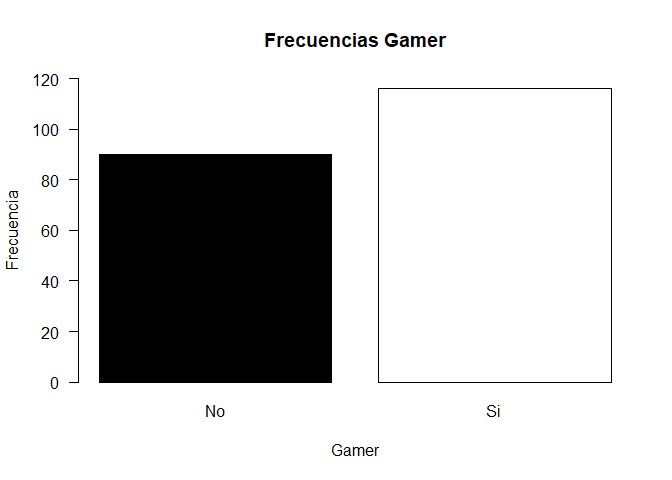

```r
barplot(table(DFN$Gamer), main="Frecuencias Gamer", xlab ="Gamer", ylab= "Frecuencia", col = c("black","white"),las=1, ylim = c(0, 120))
```

### Histograma de la variable Edad_videojuegos:

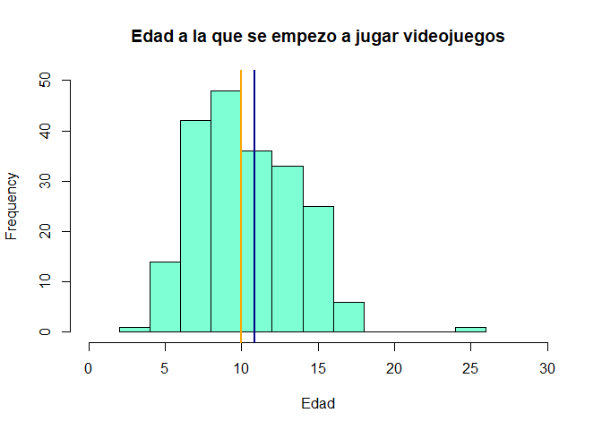

```r
hist(DFN$Edad_videojuegos,main="Edad a la que se empezo a jugar videojuegos", xlab="Edad", breaks=13, xlim = c(0, 30), ylim = c(0, 50), col = "aquamarine")
abline(v=mean(DFN$Edad_videojuegos,na.rm=TRUE),col="darkblue",lwd=2)
abline(v=median(DFN$Edad_videojuegos,na.rm=TRUE),col="orange",lwd=2)
```

#### Descriptores de tendencia y variación de la variable Edad_videojuegos:

```r
summary(DFN$Edad_videojuegos)
```

```
##    Min. 1st Qu.  Median    Mean 3rd Qu.    Max.
##    2.00    8.00   10.00   10.86   13.00   25.00
```

Desviación Estándar:

```r
SD = sd(DFN$Edad_videojuegos, na.rm=TRUE)
redondeo(SD)
```

```
## [1] 3.34
```

Varianza:

```r
redondeo(var(DFN$Edad_videojuegos, na.rm=TRUE))
```

```
## [1] 11.13
```

Coeficiente de variación:

```r
CV = (SD / mean(DFN$Edad_videojuegos,na.rm=TRUE)) * 100
redondeo(CV)
```

```
## [1] 30.71
```

### Barplot de la variable Plataforma:

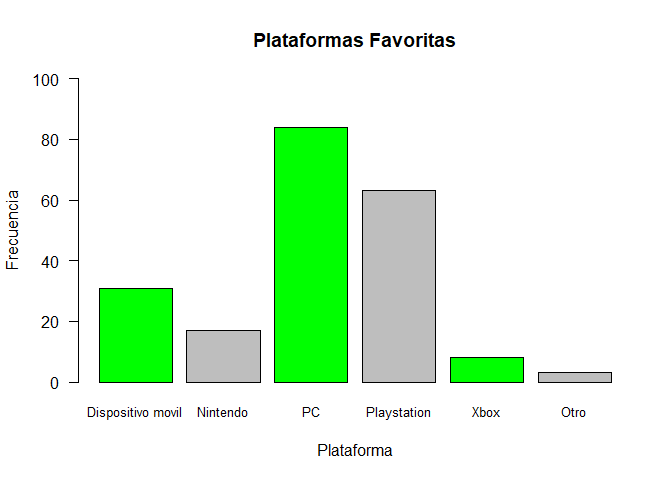

```r
barplot(table(DFN$Plataforma),main="Plataformas Favoritas", xlab ="Plataforma", ylab= "Frecuencia", col = c("green","grey"),las=1, ylim = c(0, 100), cex.names=0.8)
```

### Barplot de la variable Genero_favorito:

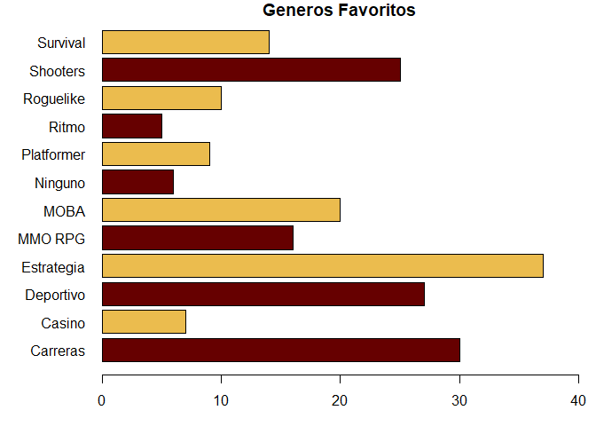

```r
par(mar=c(3,6,1,1))
barplot(table(DFN$Genero_favorito),main="Generos Favoritos",horiz=TRUE,  xlim=c(0,40), xlab= "Frecuencia", col = c("#660000","#EBBC4E"),las=1,)
```

### Barplot de la variable Dinero:

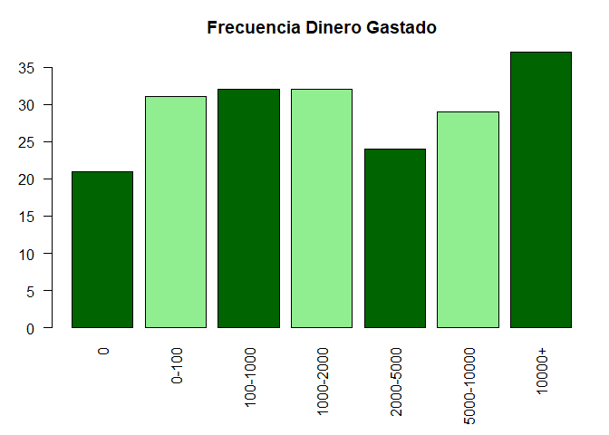

```r
par(mar=c(6,3,3,1))
barplot(table(DFN$Dinero),main="Frecuencia Dinero Gastado",las=2, col=c("dark green","light green"))
```

### Boxplot de la varibale Horas_pandemia:

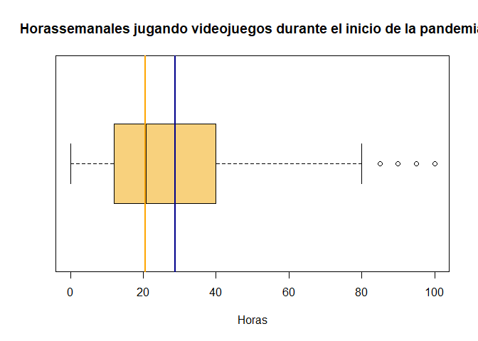

```r
boxplot(DFN$Horas_pandemia ,xlab="Horas",main="Horassemanales jugando videojuegos durante el inicio de la pandemia",horizontal=TRUE, col = "#F8D17D")
abline(v=mean(DFN$Horas_pandemia,na.rm=TRUE),col="darkblue",lwd=2)
abline(v=median(DFN$Horas_pandemia,na.rm=TRUE),col="orange",lwd=2)
```

#### Descriptores de tendencia y variación de la variable Horas_pandemia:

```r
summary(DFN$Horas_pandemia)
```

```
##    Min. 1st Qu.  Median    Mean 3rd Qu.    Max.
##     0.0    12.0    20.5    28.8    40.0   100.0
```

Desviación Estándar:

```r
SD = sd(DFN$Horas_pandemia, na.rm=TRUE)
redondeo(SD)
```

```
## [1] 22.43
```

Varianza:

```r
redondeo(var(DFN$Horas_pandemia, na.rm=TRUE))
```

```
## [1] 503.32
```

Coeficiente de variación:

```r
CV = (SD / mean(DFN$Horas_pandemia,na.rm=TRUE)) * 100
redondeo(CV)
```

```
## [1] 77.91
```

### Boxplot de la variable Horas_actuales:

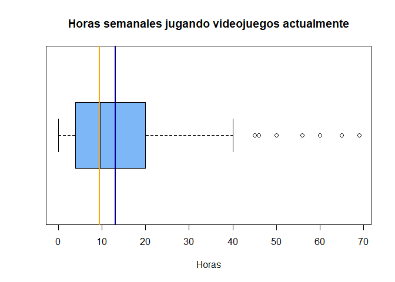

```r
boxplot(DFN$Horas_actuales ,xlab="Horas",main="Horas semanales jugando videojuegos actualmente",horizontal=TRUE, col = "#7DB7F8")
abline(v=mean(DFN$Horas_actuales,na.rm=TRUE),col="darkblue",lwd=2)
abline(v=median(DFN$Horas_actuales,na.rm=TRUE),col="orange",lwd=2)
```

#### Descriptores de tendencia y variación de la variable Horas_actuales:

```r
summary(DFN$Horas_actuales)
```

```
##    Min. 1st Qu.  Median    Mean 3rd Qu.    Max.
##    0.00    4.00    9.50   13.14   20.00   69.00
```

Desviación Estándar:

```r
SD = sd(DFN$Horas_actuales, na.rm=TRUE)
redondeo(SD)
```

```
## [1] 12.88
```

Varianza:

```r
redondeo(var(DFN$Horas_actuales, na.rm=TRUE))
```

```
## [1] 165.86
```

Coeficiente de variación:

```r
CV = (SD / mean(DFN$Horas_actuales,na.rm=TRUE)) * 100
redondeo(CV)
```

```
## [1] 98.04
```

### Boxplot de la variable Horas_estudio:

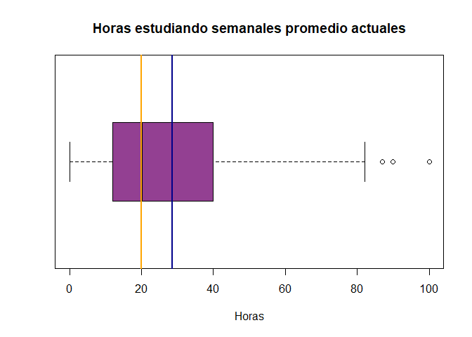

```r
boxplot(DFN$Horas_estudio ,xlab="Horas",main="Horas estudiando semanales promedio actuales",horizontal=TRUE, col = "#934092")
abline(v=mean(DFN$Horas_estudio,na.rm=TRUE),col="darkblue",lwd=2)
abline(v=median(DFN$Horas_estudio,na.rm=TRUE),col="orange",lwd=2)
```

#### Descriptores de tendencia y variación de la variable Horas_estudio:

```r
summary(DFN$Horas_estudio)
```

```
##    Min. 1st Qu.  Median    Mean 3rd Qu.    Max.
##    0.00   12.00   20.00   28.65   40.00  100.00
```

Desviación Estándar:

```r
SD = sd(DFN$Horas_estudio, na.rm=TRUE)
redondeo(SD)
```

```
## [1] 21.62
```

Varianza:

```r
redondeo(var(DFN$Horas_estudio, na.rm=TRUE))
```

```
## [1] 467.48
```

Coeficiente de variación:

```r
CV = (SD / mean(DFN$Horas_estudio,na.rm=TRUE)) * 100
redondeo(CV)
```

```
## [1] 75.47
```

### Barplot de la variable Afecta:

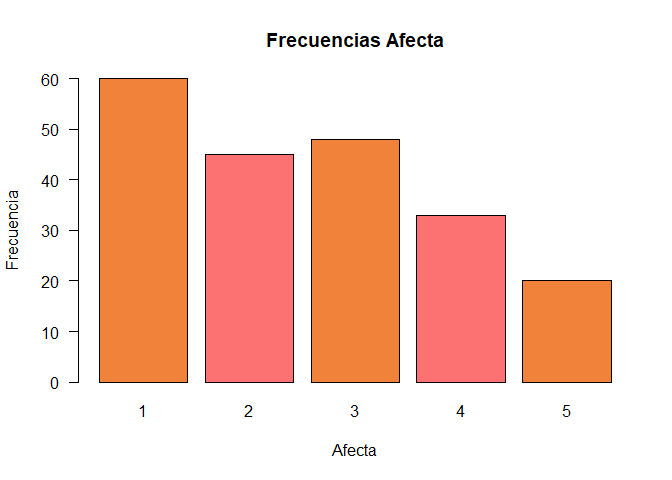

```r
barplot(table(DFN$Afecta),main="Frecuencias Afecta", xlab ="Afecta", ylab= "Frecuencia", col = c("#F1823A","#FC7171"),las=1, ylim = c(0, 60))
```

## **Análisis bivariable**

```r
NUM<-select(DFN,Edad,Promedio_ponderado,Edad_videojuegos,Horas_actuales,Horas_pandemia,Horas_actuales,Horas_estudio)
```

```r
NUM<-na.omit(NUM)
```

### Correlación:

```r
cor(NUM)
```

```
##                           Edad Promedio_ponderado Edad_videojuegos
## Edad                1.00000000        -0.19514335       0.07265898
## Promedio_ponderado -0.19514335         1.00000000       0.01360811
## Edad_videojuegos    0.07265898         0.01360811       1.00000000
## Horas_actuales      0.00462941        -0.01956530      -0.05090078
## Horas_pandemia      0.04341021         0.04433935      -0.01820064
## Horas_estudio       0.14443108         0.12180029       0.14120752
##                    Horas_actuales Horas_pandemia Horas_estudio
## Edad                   0.00462941     0.04341021     0.1444311
## Promedio_ponderado    -0.01956530     0.04433935     0.1218003
## Edad_videojuegos      -0.05090078    -0.01820064     0.1412075
## Horas_actuales         1.00000000     0.69541383     0.2059841
## Horas_pandemia         0.69541383     1.00000000     0.4274922
## Horas_estudio          0.20598413     0.42749219     1.0000000
```

```r
correlac<-cor(NUM)
```

```r
DFN$Afecta<-as.character(DFN$Afecta)
```

## Gráfica de calor

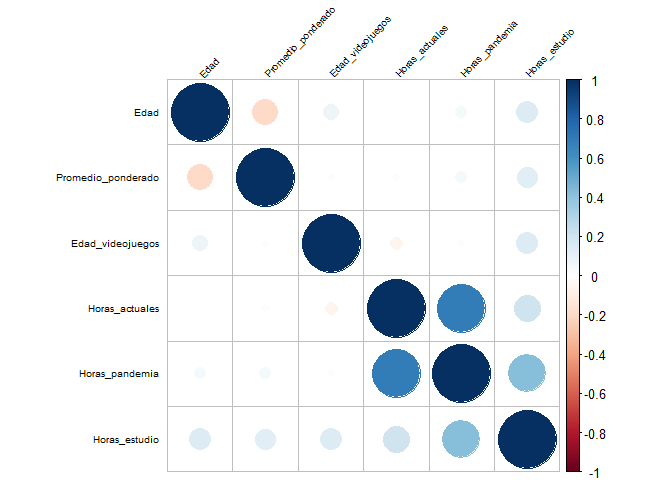

```r
library(corrplot)
corrplot(cor(NUM),tl.col = "black",tl.cex = 0.6,tl.srt = 45)
```

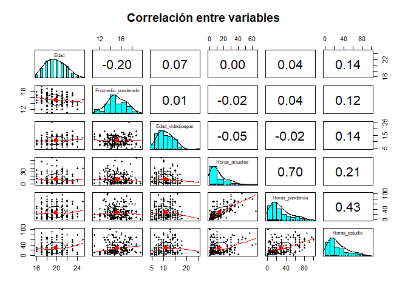

```r
pairs.panels(NUM,main="Correlación entre variables")
```

## Análisis:

En esta gráfica apreciamos la correlación entre nuestras variables numéricas, junto a sus coeficientes respectivos.

# Relación: Horas_pandemia vs Horas_actuales

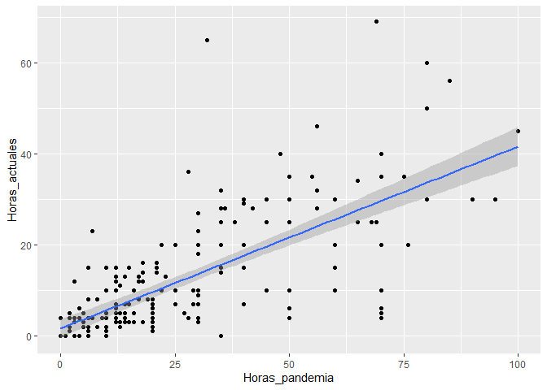

```r
ggplot(data=DFN,mapping = aes(x=Horas_pandemia,y=Horas_actuales))+geom_point()+geom_smooth(method = "lm")
```

## Análisis:

Podemos observar que la relación entre ambas, Horas_pandemia y Horas_actuales, es lineal, positiva y fuerte, a juzgar por el valor del coeficiente de correlación (mostrado a continuación).

Correlación entre variables:

```r
cor.test(DFN$Horas_actuales,DFN$Horas_pandemia)
```

```
##
##  Pearson's product-moment correlation
##
## data:  DFN$Horas_actuales and DFN$Horas_pandemia
## t = 13.843, df = 204, p-value < 2.2e-16
## alternative hypothesis: true correlation is not equal to 0
## 95 percent confidence interval:
##  0.6180765 0.7603362
## sample estimates:
##       cor
## 0.6959737
```

Variación entre variables:

```r
var.test(DFN$Horas_actuales,DFN$Horas_pandemia)
```

```
##
##  F test to compare two variances
##
## data:  DFN$Horas_actuales and DFN$Horas_pandemia
## F = 0.32954, num df = 205, denom df = 205, p-value = 9.434e-15
## alternative hypothesis: true ratio of variances is not equal to 1
## 95 percent confidence interval:
##  0.2504223 0.4336483
## sample estimates:
## ratio of variances
##          0.3295379
```

# Relación: Horas_actuales vs Horas_estudio

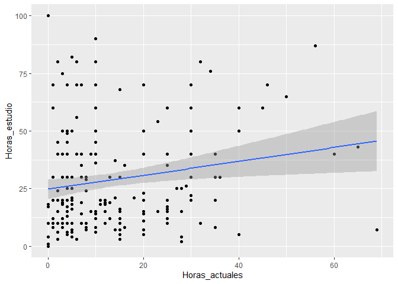

```r
ggplot(data=DFN,mapping = aes(x=Horas_actuales,y=Horas_estudio))+geom_point()+geom_smooth(method = "lm")
```

## Análisis:

Ligera correlación positiva entre Horas_actuales y Horas_estudio.

Correlación entre variables:

```r
cor.test(DFN$Horas_actuales,DFN$Horas_estudio)
```

```
##
##  Pearson's product-moment correlation
##
## data:  DFN$Horas_actuales and DFN$Horas_estudio
## t = 2.618, df = 204, p-value = 0.009508
## alternative hypothesis: true correlation is not equal to 0
## 95 percent confidence interval:
##  0.04469376 0.30936998
## sample estimates:
##       cor
## 0.1802935
```

Variación entre variables:

```r
var.test(DFN$Horas_actuales,DFN$Horas_estudio)
```

```
##
##  F test to compare two variances
##
## data:  DFN$Horas_actuales and DFN$Horas_estudio
## F = 0.35481, num df = 205, denom df = 205, p-value = 4.086e-13
## alternative hypothesis: true ratio of variances is not equal to 1
## 95 percent confidence interval:
##  0.2696251 0.4669011
## sample estimates:
## ratio of variances
##          0.3548073
```

# Relación: Universidad vs Dinero

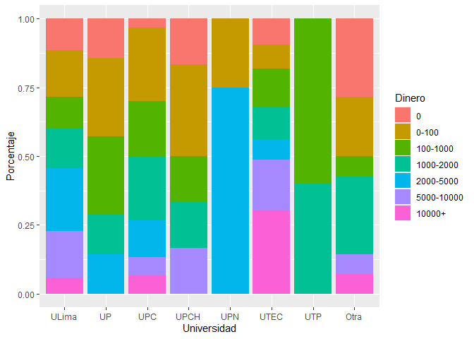

```r
uu<-DFN%>%
  group_by(Universidad)%>%
  count(Dinero)%>%
  mutate(Porcentaje=(n/sum(n)))

ggplot(uu,aes(x=Universidad,y=Porcentaje,fill=Dinero))+geom_bar(stat="identity",position = "stack")
```

## Análisis:

En esta gráfica se aprecia que los estudiantes la universidad UTEC son los que invierten más capital en videojuegos y/o equipos de juego.

# Relación: Carrera vs Horas_actuales

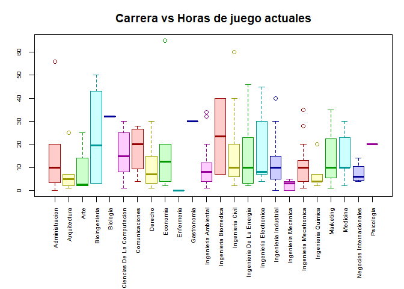

```r
par(mar=c(8,3,3,1))
boxplot(DFN$Horas_actuales ~ DFN$Carrera,main = "Carrera vs Horas de juego actuales",
        ylab = "Horas actuales",
        xlab = "",
        col = rainbow(6, alpha=0.2),
        border = rainbow(6, v=0.6), las=3, cex.axis=0.6
        )
```

# Relación: Universidad vs Gamer

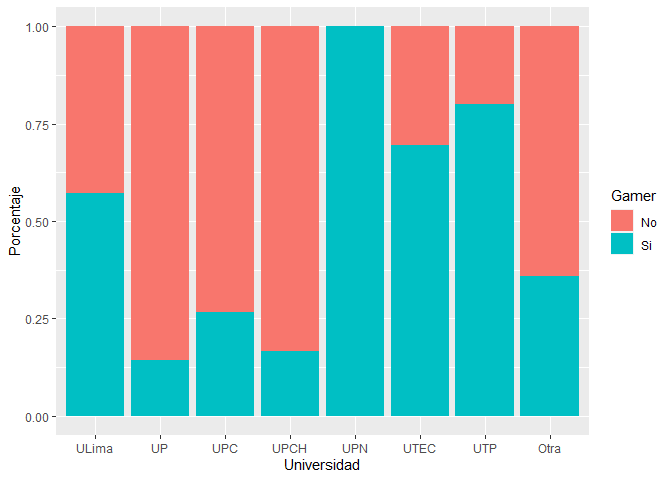

```r
uG<-DFN%>%
  group_by(Universidad)%>%
  count(Gamer)%>%
  mutate(Porcentaje=(n/sum(n)))

ggplot(uG,aes(x=Universidad,y=Porcentaje,fill=Gamer))+geom_bar(stat="identity",position = "stack")
```

## Análisis:

En esta gráfica se aprecia que los estudiantes encuestados que pertenecen a la UPN se consideran Gamers.

# Relación: Sexo vs Dinero

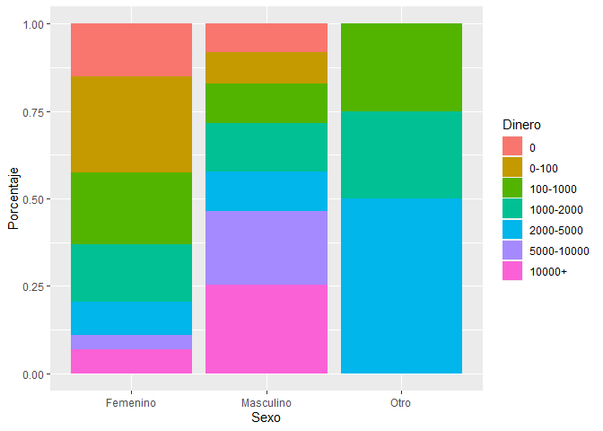

```r
TEMP<-na.omit(DFN)
SD<-TEMP%>%
  group_by(Sexo)%>%
  count(Dinero)%>%
  mutate(Porcentaje=(n/sum(n)))

ggplot(SD,aes(x=Sexo,y=Porcentaje,fill=Dinero))+geom_bar(stat="identity",position = "stack")+ scale_color_discrete(labels = c('0','0-100','100-1000','2000-5000','5000-10000','10000+'))
```

# Relación: Sexo vs Gamer

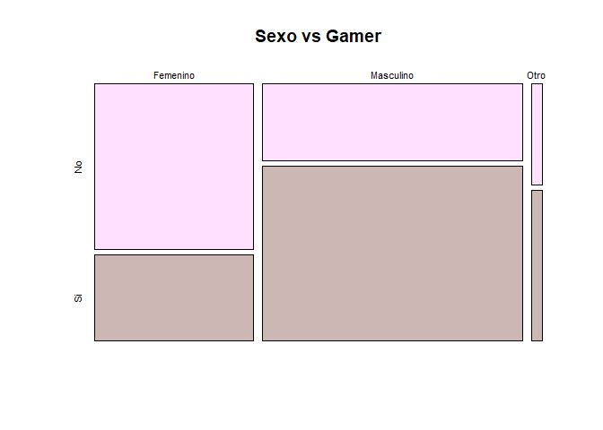

```r
mosaicplot(table(DFN$Sexo,DFN$Gamer),main = "Sexo vs Gamer",col=c("thistle1", "mistyrose3"))
```

## Análisis:

En esta gráfica se aprecia que en su gran mayoría, los hombres reconocen ser Gamers a comparación de las mujeres que no suelen considerarse Gamers.

# Relación: Sexo vs Genero_favorito

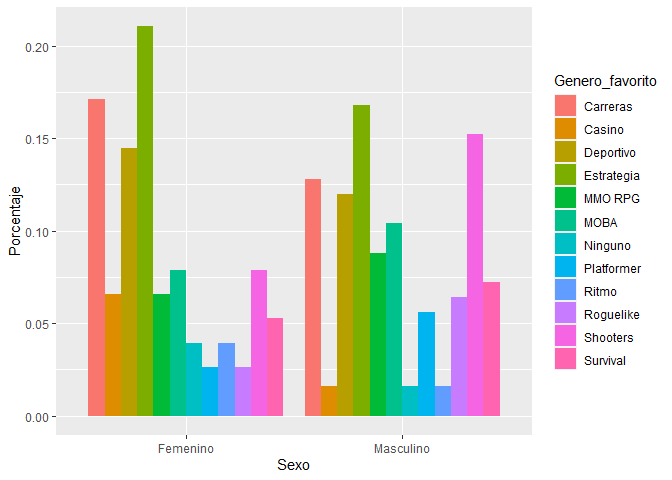

```r
XD <- filter(DFN,DFN$Sexo != "Otro")
SG <- XD%>%
  group_by(Sexo)%>%
  count(Genero_favorito)%>%
  mutate(Porcentaje=(n/sum(n)))

ggplot(SG,aes(x=Sexo,y=Porcentaje,fill=Genero_favorito))+geom_bar(stat="identity",position = "dodge")
```

## Análisis:

En esta gráfica se aprecia que tanto hombres como mujeres prefieren el genero de estrategia pero que a diferencia de las mujeres, los hombres también suelen jugar Shooters tanto como las mujeres juegan de carreras.

# Relación: Plataformas vs Edad

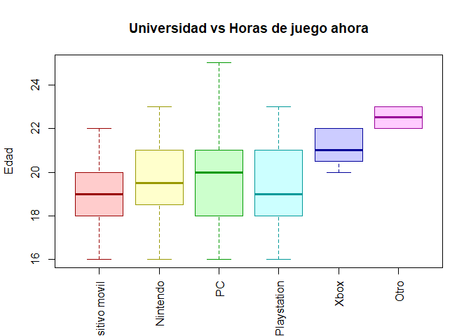

```r
boxplot(DFN$Edad ~ DFN$Plataforma,main = "Universidad vs Horas de juego ahora",
        ylab = "Edad",
        xlab ="",
        col = rainbow(6, alpha=0.2),
        border = rainbow(6, v=0.6), las=3
        )
```

# Relación: Afecta vs Dinero

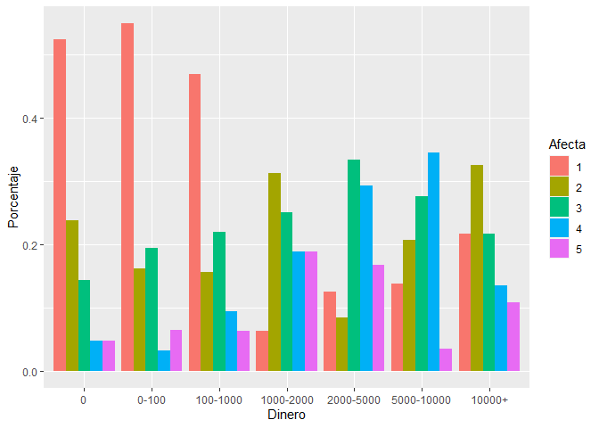

```r
AD<-DFN%>%
  group_by(Dinero)%>%
  count(Afecta)%>%
  mutate(Porcentaje=(n/sum(n)))

ggplot(AD,aes(x=Dinero,y=Porcentaje,fill=Afecta))+geom_bar(stat="identity",position = "dodge")
```

## Análisis:

# Relación: Afecta vs Horas_estudio

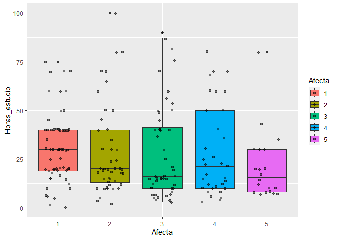

```r
ggplot(DFN,aes(x=Afecta, y=Horas_estudio, fill=Afecta)) +

      geom_boxplot()+geom_jitter(width=0.25, alpha=0.5)
```

## Análisis:

Lo mas importante que podemos concluir de esta gráfica es que las personas que consideran que los videojuegos les afecta en los estudios son aquellas que menos tiempo le dedican a este.

# Relación: Afecta vs Horas_actuales

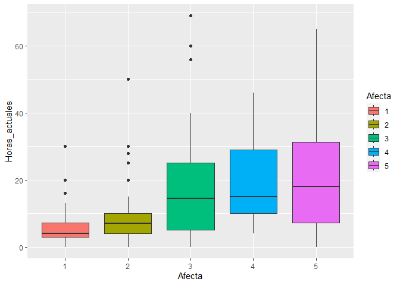

```r
ggplot(DFN,aes(x=Afecta, y=Horas_actuales, fill=Afecta)) +
      geom_boxplot()
```

## Análisis:

Esta gráfica nos ayuda a concluir que aquellos encuestados que consideran que les afecta menos, son los que les dedican menos tiempo a los videojuegos, así como aquellos encuestados que consideran que les afecta más son aquellos que le dedican mas tiempo a los videojuegos.

# Relación: Afecta vs Promedio

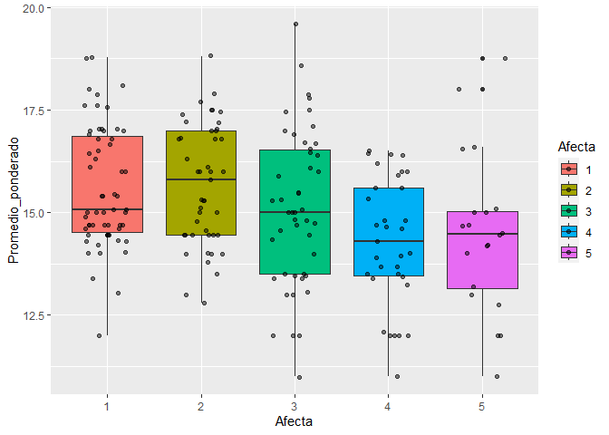

```r
ggplot(DFN,aes(x=Afecta, y=Promedio_ponderado, fill=Afecta)) +
      geom_boxplot()+geom_jitter(width=0.25, alpha=0.5)
```

## Análisis:

Lo mas importante que podemos rescatar de esta gráfica es que aquellas personas que consideran que más les afecta los videojuegos son aquellas que tienes menos puntaje en su promedio ponderado.

# Relación: Afecta vs Gamer

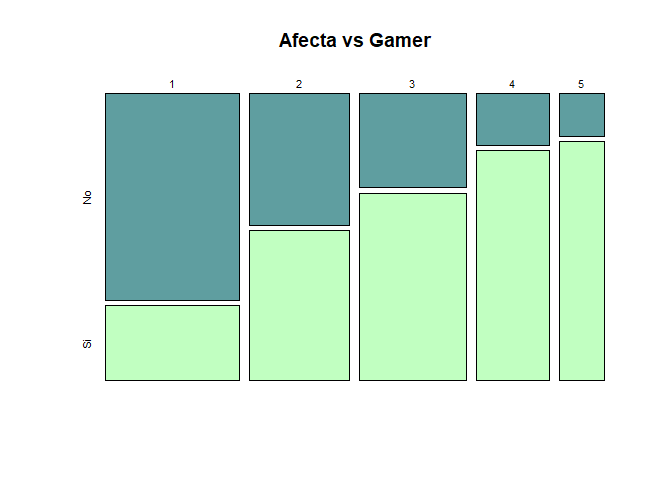

```r
mosaicplot(table(DFN$Afecta,DFN$Gamer),main = "Afecta vs Gamer",col=c("cadetblue", "darkseagreen1"))
```

## Análisis:

Aquellas personas que se consideran gamer son a las que mas les afecta en los estudios.

# Relación: Edad vs Horas_actuales

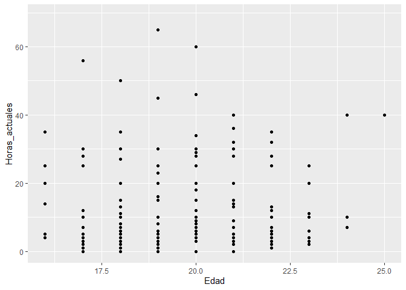

```r
ggplot(data=DFN,mapping = aes(x=Edad,y=Horas_actuales))+geom_point()
```

## Análisis:

Con esta gráfica podemos concluir que la edad no influye en las cantidad de horas que le dedican a los videojuegos, a juzgar bor el bajo valor del coeficiente de correlación.

Correlación entre variables:

```r
cor.test(DFN$Edad,DFN$Horas_actuales)
```

```
##
##  Pearson's product-moment correlation
##
## data:  DFN$Edad and DFN$Horas_actuales
## t = 0.16103, df = 202, p-value = 0.8722
## alternative hypothesis: true correlation is not equal to 0
## 95 percent confidence interval:
##  -0.1262382  0.1484696
## sample estimates:
##        cor
## 0.01132945
```

Variación entre variables:

```r
var.test(DFN$Edad,DFN$Horas_actuales)
```

```
##
##  F test to compare two variances
##
## data:  DFN$Edad and DFN$Horas_actuales
## F = 0.022027, num df = 203, denom df = 205, p-value < 2.2e-16
## alternative hypothesis: true ratio of variances is not equal to 1
## 95 percent confidence interval:
##  0.01672901 0.02900847
## sample estimates:
## ratio of variances
##         0.02202707
```

# Relación: Edad_videojuegos vs Horas_actuales

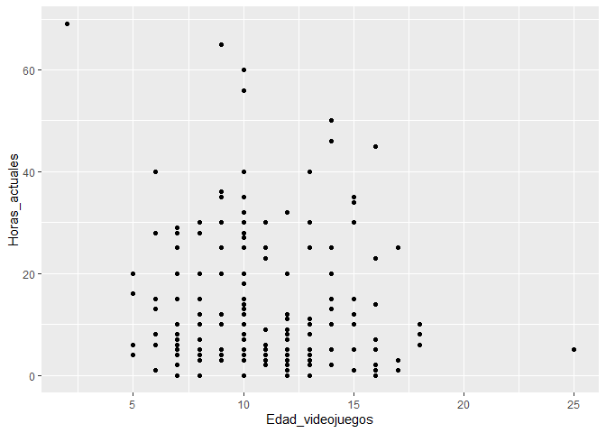

```r
ggplot(data=DFN,mapping = aes(x=Edad_videojuegos,y=Horas_actuales))+geom_point()
```

## Análisis:

Con esta gráfica podemos concluir que la edad en la que los encuestados comenzaron a jugar videojuegos no influye en las horas actuales que dedican a ello.

Correlación entre variables:

```r
cor.test(DFN$Edad_videojuegos,DFN$Horas_actuales)
```

```
##
##  Pearson's product-moment correlation
##
## data:  DFN$Edad_videojuegos and DFN$Horas_actuales
## t = -1.3948, df = 204, p-value = 0.1646
## alternative hypothesis: true correlation is not equal to 0
## 95 percent confidence interval:
##  -0.2308290  0.0400386
## sample estimates:
##         cor
## -0.09719468
```

Variación entre variables:

```r
var.test(DFN$Edad_videojuegos,DFN$Horas_actuales)
```

```
##
##  F test to compare two variances
##
## data:  DFN$Edad_videojuegos and DFN$Horas_actuales
## F = 0.067119, num df = 205, denom df = 205, p-value < 2.2e-16
## alternative hypothesis: true ratio of variances is not equal to 1
## 95 percent confidence interval:
##  0.05100507 0.08832384
## sample estimates:
## ratio of variances
##         0.06711903
```